# Multiple Linear Regression Using R

Etana Disasa

5/24/2019

```r
rm(list = ls())
suppressMessages(library(MASS))   # This library needs to be called in order to access the Boston dataset.
suppressMessages(library(caret))  # This library is called for the 'cor' function--measures correlations between to variables--to work.
suppressMessages(library(graphics))# The 'abline' command uses this library.
library(fmsb)
library(ggplot2)
library(LICORS)
```

# Introduction

Multiple Linear Regression is a common form of linear regression analysis that is utilized to explain relationships between one continuous dependent variable and two or more independent variables. The dependent variable can also be called the outcome variable or regressand and the independent variables as predictor variables or regressors. This assignment attepts to perform multiple linear regression analysis using using variables from the Boston dataset.

# Multiple Linear Regression

For this assignment, the regressand chosen is ‘tax’ which is full-value property-tax rate per $10,000. The regressors chosen are ‘dis’–weighted mean of distances to five Boston employment centers–, ‘age’–proprotion of ownern-occupied units build prior to 1940, and ‘medv’–median value of owner-occupied homes in $1000s.

### Data Exploration

The full-value property-tax rate ranges from 187 to 711 with a median of 330. The weighted mean of distances to five Boston employment centers rantes from 1.1296 to 12.1265 with a median of 3.20745. The proportion of owner-occupied units built prior to 1940 ranges from 2.9 to 100 with median of 77.5. The median value of owner-occupied homes in $1000s range from 5 to 50 with median of 21.2.

```r
summary(Boston$tax)
```

```
##    Min. 1st Qu.  Median    Mean 3rd Qu.    Max.
##   187.0   279.0   330.0   408.2   666.0   711.0
```

```r
summary(Boston$dis)
```

```
##    Min. 1st Qu.  Median    Mean 3rd Qu.    Max.
##   1.130   2.100   3.207   3.795   5.188  12.127
```

```r
summary(Boston$age)
```

```
##    Min. 1st Qu.  Median    Mean 3rd Qu.    Max.
##    2.90   45.02   77.50   68.57   94.08  100.00
```

```r
summary(Boston$medv)
```

```
##    Min. 1st Qu.  Median    Mean 3rd Qu.    Max.
##    5.00   17.02   21.20   22.53   25.00   50.00
```

### Correlation

There is a negative correlation of **-0.5344316** between ‘tax’ and ‘dis’. However, there is also a positive correlation of **0.5064556** between ‘tax’ and ‘age’. There is also a negative correlation of **-0.4685359** between ‘tax’ and ‘medv’. Below is three correlation graphs between tax and dis, tax and age, and tax and medv.

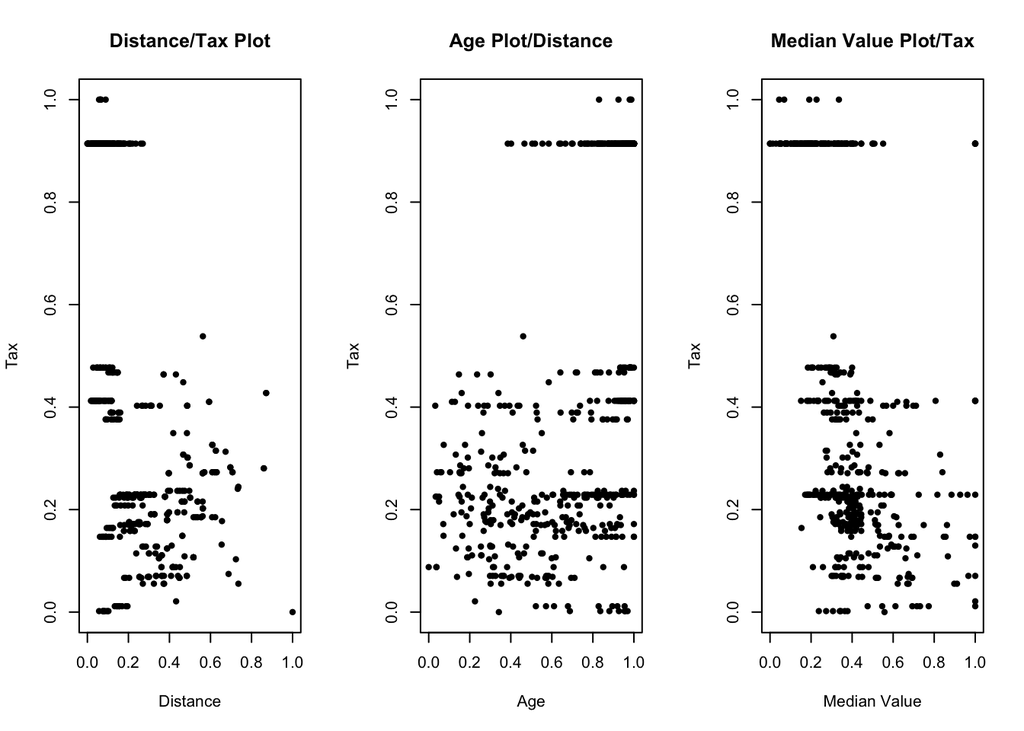

```r
normalizer <- function(x)
{
  return((x-min(x)) / (max(x)-min(x)))
}
tax <-normalizer(Boston$tax)
dis <-normalizer(Boston$dis)
age <-normalizer(Boston$age)
medv <- normalizer(Boston$medv)
par (mfrow=c(1,3))
plot(dis,tax, pch = 20, ylab = 'Tax', xlab = 'Distance', main = 'Distance/Tax Plot')
plot(age,tax, pch = 20, ylab = 'Tax', xlab = 'Age', main = 'Age Plot/Distance')
plot(medv,tax, pch = 20, ylab = 'Tax', xlab = 'Median Value', main = 'Median Value Plot/Tax')
```

The linear correlations that exists between these variables is not indicative of multiple linear correlation. Therefore, performing multiple linear regression helps understand if there is such multicorrelation between the regressan (dependant variable) and regressors (independant variables). Multiple linear regression helps us understand how much the dependant variable changes as we change the independent variables. The question then could be devised as, “**Is there any multicollinearity between the independant variables and the dependant variable?”** which explores if the independant variables are highly correlated?"

### Performing Multiple Linear Regression

The Null Hypothesis and the Alternative Hypothesis are as follows.

**H<sub>0</sub>: There is no significant prediction of full-value property-tax rate by the mean distances of five Boston employment centers, by the proportion of owner-occupied units built prior to 1940 and by the median value of owner-occupied homes.**

**H<sub>1</sub>: There is a significant prediction of full-value property-tax rate by the mean distances of five Boston employment centers and by the proportion of owner-occupied units built prior to 1940 and by the median value of owner-occupied homes.**

```r
regression1 <- lm(Boston$tax~Boston$dis + Boston$age + Boston$medv)
summary(regression1)
```

```
##
## Call:
## lm(formula = Boston$tax ~ Boston$dis + Boston$age + Boston$medv)
##
## Residuals:
##     Min      1Q  Median      3Q     Max
## -339.77 -101.55  -28.42  106.28  337.68
##
## Coefficients:
##             Estimate Std. Error t value Pr(>|t|)
## (Intercept) 622.7350    41.7594  14.912  < 2e-16 ***
## Boston$dis  -30.2345     4.1424  -7.299 1.14e-12 ***
## Boston$age    0.5787     0.3239   1.786   0.0746 .
## Boston$medv  -6.1882     0.6797  -9.104  < 2e-16 ***
## ---
## Signif. codes:  0 '***' 0.001 '**' 0.01 '*' 0.05 '.' 0.1 ' ' 1
##
## Residual standard error: 129.9 on 502 degrees of freedom
## Multiple R-squared:  0.4091, Adjusted R-squared:  0.4055
## F-statistic: 115.8 on 3 and 502 DF,  p-value: < 2.2e-16
```

```r
regression1$coefficients
```

```
## (Intercept)  Boston$dis  Boston$age Boston$medv
## 622.7349972 -30.2345244   0.5786632  -6.1882351
```

The summary of the regression model an F-staticstics of 115.8 on 3 and 502 DF. The overall p-value is less than 2.2e-16 which is significantly low. Therefore, per our findings, we reject the Null Hypothesis. Thus, there is a significant prediction of full-value property-tax rate by the mean distances of five Boston employment centers and by the proportion of owner-occupied units built prior to 1940 and by the median value of owner-occupied homes.

### Discussing Each Independant Variable

#### 1. ‘Boston$dis’

The first independant variable is ‘dis’. The Null and the Alternative Hypothesis are as follows

**H<sub>0</sub>: There is not a significant prediction of full-value property-tax rate by the mean distances of five Boston employment centers.**

**H<sub>1</sub>: There is a significant prediction of full-value property-tax rate by the mean distances of five Boston employment centers.**

Per our findings the P-value for variable ‘dis’ is 1.14e-12 which is smaller than 0.05 that is highly significant. Therefore, we reject the Null Hypothesis. Thus, there is a significant prediction of full-value property-tax rate by the mean distances of five Boston employment centers.

#### 2. ‘Boston$age’

The second independant variable utilized is ‘age’. The Null and the Alternative Hypothesis are as follows.

**H<sub>0</sub>: There is not a significant prediction of full-value property-tax rate by the proportion of owner-occupied units built prior to 1940.**

**H<sub>1</sub>: There is a significant prediction of full-value property-tax rate by the proportion of owner-occupied units built prior to 1940.**

Per our findings the P-value for variable ‘age’ is 0.0746 which is greater than 0.05 that is insignificant. Therefore, we fail to reject the Null Hypothesis. Thus, there is not a significant prediction of full-value property-tax rate by the proportion of owner-occupied units built prior to 1940.

#### 3. ‘Boston$medv’

The third independant variable utilized is ‘medv’. The Null and the Alternative Hypothesis are as follows.

**H<sub>0</sub>: There is not a significant prediction of full-value property-tax rate by the median value of owner-occupied homes in $1000s.**

**H<sub>1</sub>: There is a significant prediction of full-value property-tax rate by the median value of owner-occupied homes in $1000s.**

Per our findings the P-value for variable ‘medv’ is less than 2e-16 which is lower than 0.05 that is highly significant. Therefore, we reject the Null Hypothesis. Thus, there is a significant prediction of full-value property-tax rate by the median value of owner-occupied homes in $1000s.

In conclusion, the two predictors (‘dis’ and ‘medv’) causes us to reject the Null Hypothesis. However, one predictor (‘age’) causes us to fail to reject the Null Hypothesis. Thus, from the coefficients of variables, which are *622.7349972, -30.2345244, 0.5786632, -6.1882351*, we construct our model for predicting the tax as

**Tax = 622.7349972 - 30.2345244xDis + 0.5786632xAge - 6.1882351xMedv**

### Alternative Regression Models

```r
regression2 <- lm(Boston$tax~Boston$age + Boston$medv)
summary(regression2)
```

```
##
## Call:
## lm(formula = Boston$tax ~ Boston$age + Boston$medv)
##
## Residuals:
##     Min      1Q  Median      3Q     Max
## -322.97 -103.59  -23.93  122.85  372.25
##
## Coefficients:
##             Estimate Std. Error t value Pr(>|t|)
## (Intercept) 384.0031    27.2776  14.078  < 2e-16 ***
## Boston$age    2.3020     0.2330   9.878  < 2e-16 ***
## Boston$medv  -5.9301     0.7132  -8.315 8.66e-16 ***
## ---
## Signif. codes:  0 '***' 0.001 '**' 0.01 '*' 0.05 '.' 0.1 ' ' 1
##
## Residual standard error: 136.5 on 503 degrees of freedom
## Multiple R-squared:  0.3463, Adjusted R-squared:  0.3437
## F-statistic: 133.3 on 2 and 503 DF,  p-value: < 2.2e-16
```

```r
regression2$coefficients
```

```
## (Intercept)  Boston$age Boston$medv
##  384.003090    2.301957   -5.930127
```

In order to have a better understanding of these models and to conclude which model fits the data better, verifying the models is very important.

### Verifying the Two Models

Plotting ‘regression1’

Plotting ‘regression2’

Analysis

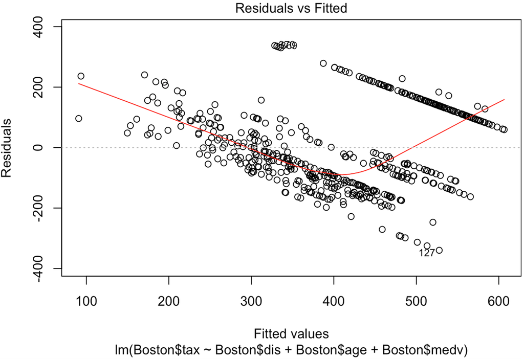

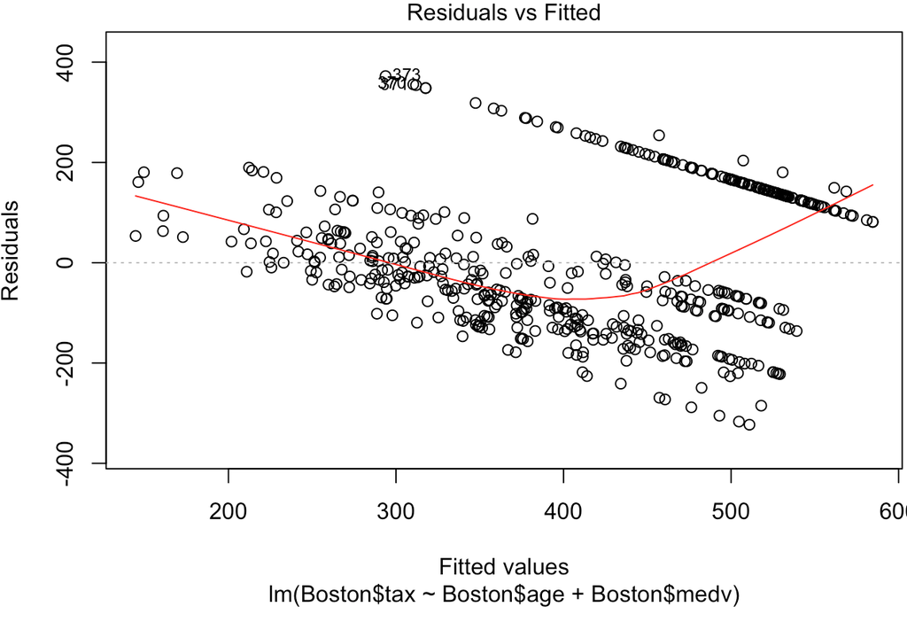

The plot on the leftshows a more distinct pattern away from the horizontal line. However, the plot on the right displays residuals more evenly scatterd along the horizontal line compared to the first plot.

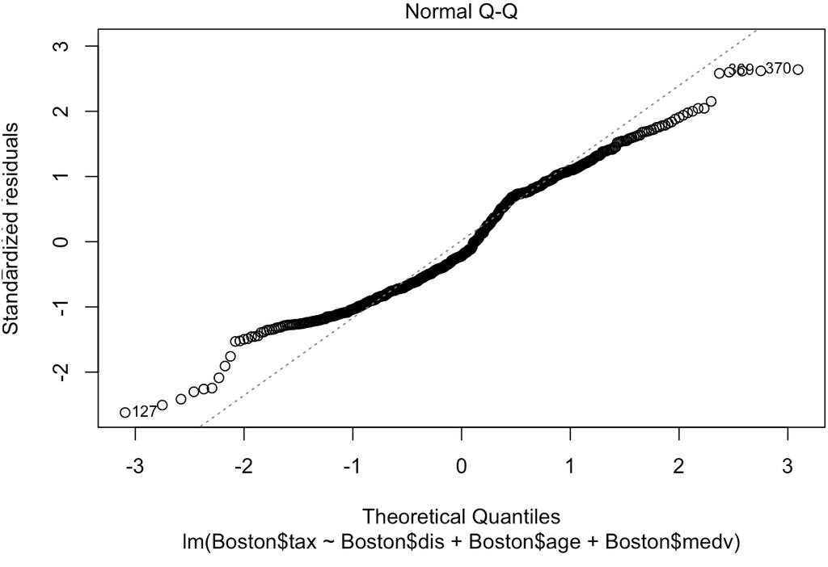

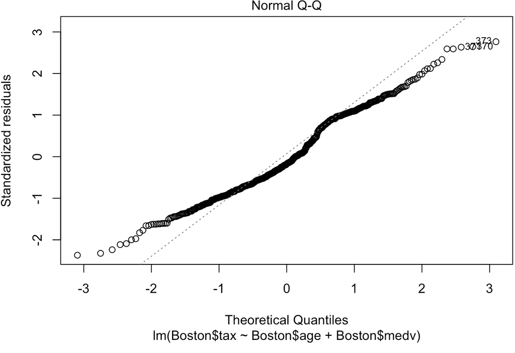

Here, the two Normal Q-Q plots do not appear to have significant difference. However, the plot on the right appears to have slightly more aligned to the dotted diagonal line than the plot on the left.

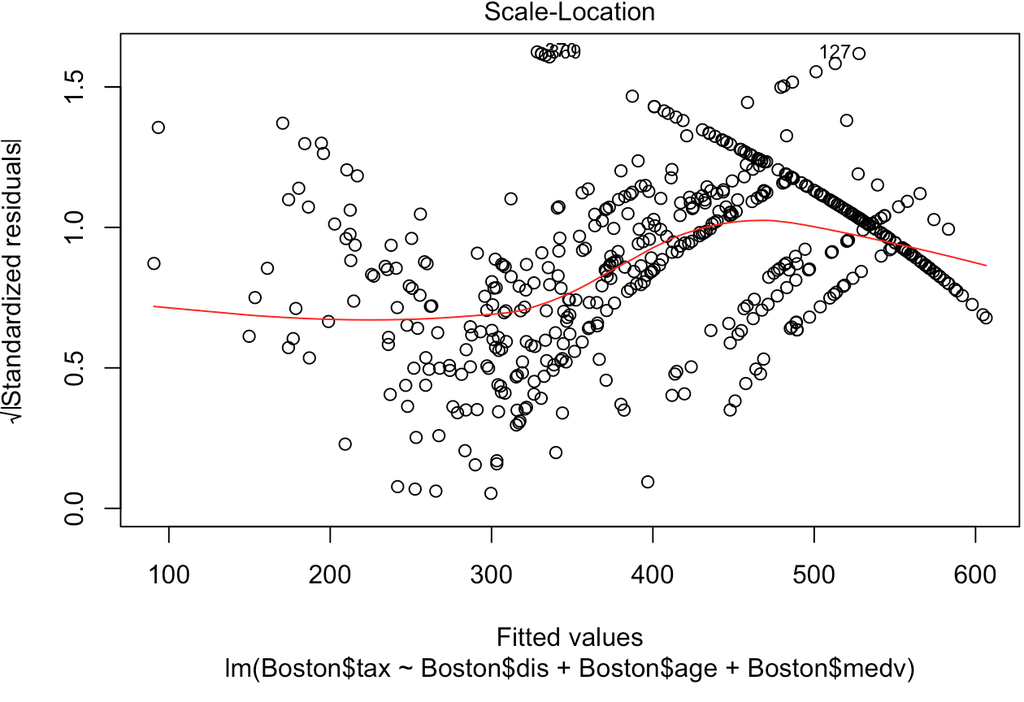

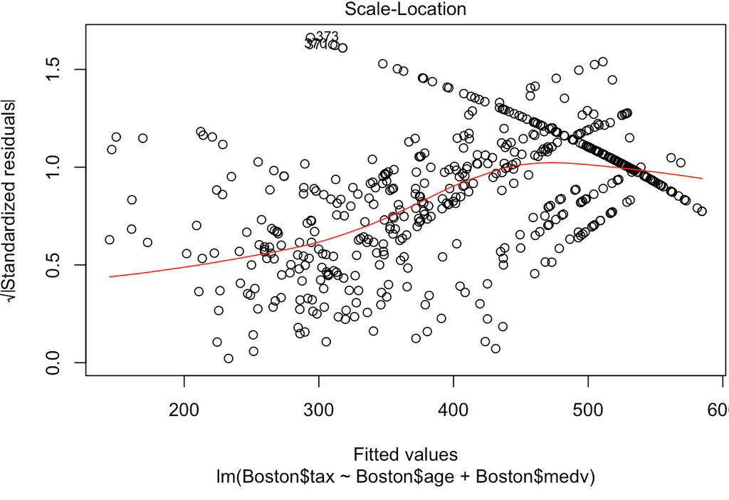

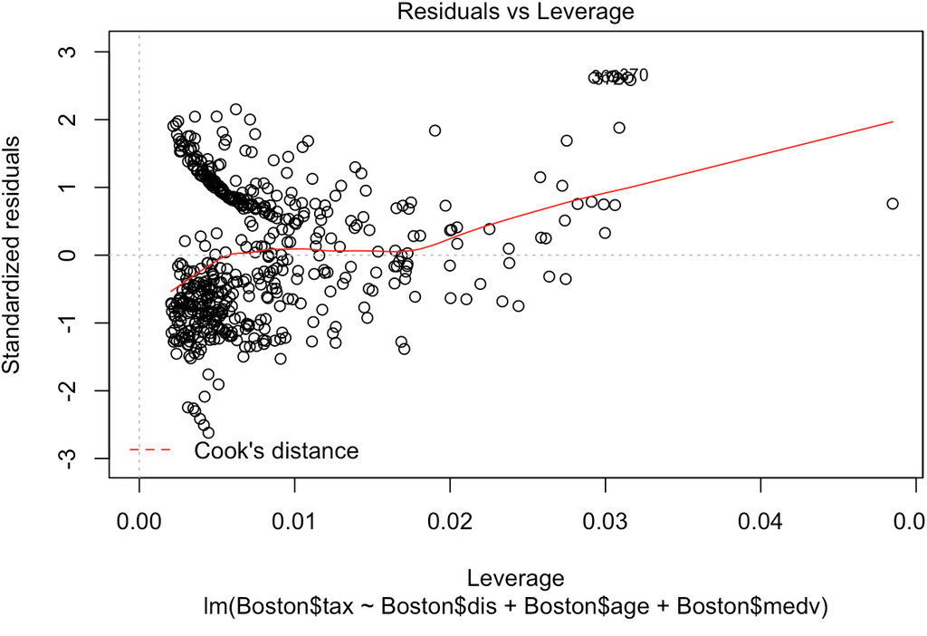

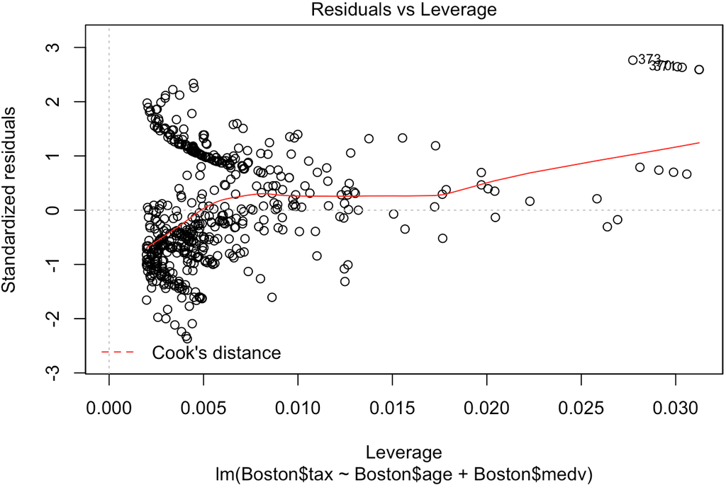

Similarly here, the two plots appear alike. However, the first plot puts the Cook’s distance much closer to -3 as oppose to the second plot which puts is a bit lower than -2.5.

### Checking Multicollinearity

Multicollinearity in multiple linear regression model is evaluated by calculating the variance inflation factor (VIF) from the model. If VIF is more than 10, it could be suggested that there is a strong multicollinearity among variables. The function used here is `VIF` code from the `fmsb` library. Our first model `regression` has a VIF score of 1.6921947 and the second model `regression2` scored a VIF of 1.5298451. In both cases the score are insignificant. Therefore, multicoliniarity may be ignored.

# Conclusion

In this assignment, two multiple linear regression models were discussed in details. Per the findings, it appears that the second model with two predictors appear to have slightly changed the model. Multicollinearity was also calculated to make sure that the predictors did not have collinearity that could significantly alter the way the model predicts.

# References

Nilsson, H., & Fox, J. (n.d.). R: Variance Inflation Factors. Retrieved June 4, 2019, from http://math.furman.edu/~dcs/courses/math47/R/library/car/html/vif.html

Curtis, S. M., & Ghosh, S. K. (2011). A Bayesian Approach to Multicollinearity and the Simultaneous Selection and Clustering of Predictors in Linear Regression. Journal of Statistical Theory and Practice, 5(4), 715–735. https://doi.org/10.1080/15598608.2011.10483741

Kim, B. (n.d.). Understanding Diagnostic Plots for Linear Regression Analysis | University of Virginia Library Research Data Services + Sciences. Retrieved June 4, 2019, from https://data.library.virginia.edu/diagnostic-plots/

Lillis, D. (n.d.). R Graphics: Multiple Graphs and par(mfrow=(A,B)) - The Analysis Factor. Retrieved June 4, 2019, from https://www.theanalysisfactor.com/r-multiple-graphs/

Deo, S. (n.d.). R Tutorial : Multiple Linear Regression – Tutorials for Data Science , Machine Learning, AI & Big Data. Retrieved June 4, 2019, from http://analyticspro.org/2016/03/02/r-tutorial-multiple-linear-regression/

R Tutorial : How to interpret F Statistic in Regression Models – Tutorials for Data Science , Machine Learning, AI & Big Data. (n.d.). Retrieved June 4, 2019, from http://analyticspro.org/2016/03/15/r-tutorial-how-to-interpret-f-statistic-in-regression-models/

R: Housing Values in Suburbs of Boston. (n.d.). Retrieved June 4, 2019, from https://stat.ethz.ch/R-manual/R-devel/library/MASS/html/Boston.html

What is Multiple Linear Regression? - Statistics Solutions. (n.d.). Retrieved June 4, 2019, from https://www.statisticssolutions.com/what-is-multiple-linear-regression/